# Data Analyst Job Market Analysis

This project seeks to explore data and analytics job postings from Glassdoor to investigate the relationships between minimum years of work experience, programming languages R and python and median salary estimates.

## Job Market Analysis Visualizations

### Experience vs. Salary Relationship

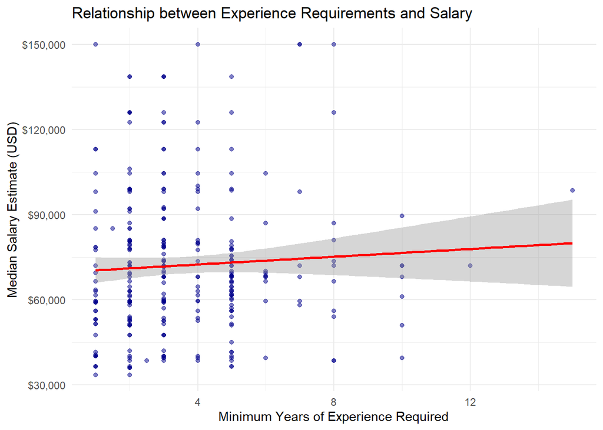

The scatter plot shows a modest positive relationship between minimum years of experience required and median salary estimates. While salaries tend to increase slightly with more experience, the trend is weak, and there is considerable variability across all experience levels. This suggests that factors beyond experience—such as job type, sector, and location—play a significant role in salary determination.

### Salary Distribution by Programming Language Requirements

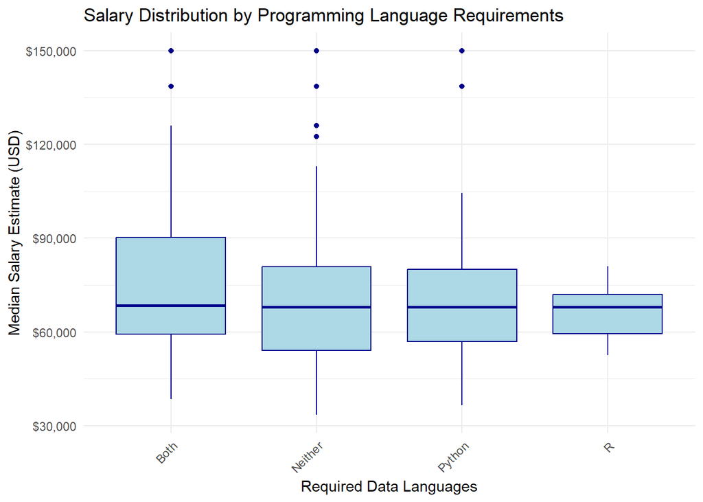

## Reflections

In this assignment I found that the development of the MY GPT function was not straightforward, I have not been able yet to go through it thoroughly enough to follow it. However, applying it is straight forward.

I was pleasantly surprised by the Cursor LLM, how it follows the prompts with great precision. I also learnt that using LLM and Google spreadsheets, I can get answers that are not so easy to get from the LLM if I just post a prompt that’s very long and a long complex input file.